# Loan Data From Prosper Exploration

## Data Wrangling

> This document explores a dataset containing 113,937 loans with 81 variables on each loan, including loan amount, borrower rate (or interest rate), current loan status, borrower income, and many others. This exploration will involve the use of 14 variables which will be a subset of the original dataset.

```python
#import all modules and set matplotlib inline
import pandas as pd
import seaborn as sns
import numpy as np
import matplotlib.pyplot as plt

%matplotlib inline
```

```python
#Reading the csv file into a pandas dataframe
file = pd.read_csv('prosperLoanData.csv')
file
```

|  | ListingKey | ListingNumber | ListingCreationDate | CreditGrade | Term | LoanStatus | ClosedDate | BorrowerAPR | BorrowerRate | LenderYield | ... | LP_ServiceFees | LP_CollectionFees | LP_GrossPrincipalLoss | LP_NetPrincipalLoss | LP_NonPrincipalRecoverypayments | PercentFunded | Recommendations | InvestmentFromFriendsCount | InvestmentFromFriendsAmount | Investors |
| --- | --- | --- | --- | --- | --- | --- | --- | --- | --- | --- | --- | --- | --- | --- | --- | --- | --- | --- | --- | --- | --- |
| 0 | 1021339766868145413AB3B | 193129 | 2007-08-26 19:09:29.263000000 | C | 36 | Completed | 2009-08-14 00:00:00 | 0.16516 | 0.1580 | 0.1380 | ... | -133.18 | 0.0 | 0.0 | 0.0 | 0.0 | 1.0 | 0 | 0 | 0.0 | 258 |
| 1 | 10273602499503308B223C1 | 1209647 | 2014-02-27 08:28:07.900000000 | NaN | 36 | Current | NaN | 0.12016 | 0.0920 | 0.0820 | ... | 0.00 | 0.0 | 0.0 | 0.0 | 0.0 | 1.0 | 0 | 0 | 0.0 | 1 |
| 2 | 0EE9337825851032864889A | 81716 | 2007-01-05 15:00:47.090000000 | HR | 36 | Completed | 2009-12-17 00:00:00 | 0.28269 | 0.2750 | 0.2400 | ... | -24.20 | 0.0 | 0.0 | 0.0 | 0.0 | 1.0 | 0 | 0 | 0.0 | 41 |
| 3 | 0EF5356002482715299901A | 658116 | 2012-10-22 11:02:35.010000000 | NaN | 36 | Current | NaN | 0.12528 | 0.0974 | 0.0874 | ... | -108.01 | 0.0 | 0.0 | 0.0 | 0.0 | 1.0 | 0 | 0 | 0.0 | 158 |
| 4 | 0F023589499656230C5E3E2 | 909464 | 2013-09-14 18:38:39.097000000 | NaN | 36 | Current | NaN | 0.24614 | 0.2085 | 0.1985 | ... | -60.27 | 0.0 | 0.0 | 0.0 | 0.0 | 1.0 | 0 | 0 | 0.0 | 20 |
| ... | ... | ... | ... | ... | ... | ... | ... | ... | ... | ... | ... | ... | ... | ... | ... | ... | ... | ... | ... | ... | ... |
| 113932 | E6D9357655724827169606C | 753087 | 2013-04-14 05:55:02.663000000 | NaN | 36 | Current | NaN | 0.22354 | 0.1864 | 0.1764 | ... | -75.58 | 0.0 | 0.0 | 0.0 | 0.0 | 1.0 | 0 | 0 | 0.0 | 1 |
| 113933 | E6DB353036033497292EE43 | 537216 | 2011-11-03 20:42:55.333000000 | NaN | 36 | FinalPaymentInProgress | NaN | 0.13220 | 0.1110 | 0.1010 | ... | -30.05 | 0.0 | 0.0 | 0.0 | 0.0 | 1.0 | 0 | 0 | 0.0 | 22 |
| 113934 | E6E13596170052029692BB1 | 1069178 | 2013-12-13 05:49:12.703000000 | NaN | 60 | Current | NaN | 0.23984 | 0.2150 | 0.2050 | ... | -16.91 | 0.0 | 0.0 | 0.0 | 0.0 | 1.0 | 0 | 0 | 0.0 | 119 |
| 113935 | E6EB3531504622671970D9E | 539056 | 2011-11-14 13:18:26.597000000 | NaN | 60 | Completed | 2013-08-13 00:00:00 | 0.28408 | 0.2605 | 0.2505 | ... | -235.05 | 0.0 | 0.0 | 0.0 | 0.0 | 1.0 | 0 | 0 | 0.0 | 274 |
| 113936 | E6ED3600409833199F711B7 | 1140093 | 2014-01-15 09:27:37.657000000 | NaN | 36 | Current | NaN | 0.13189 | 0.1039 | 0.0939 | ... | -1.70 | 0.0 | 0.0 | 0.0 | 0.0 | 1.0 | 0 | 0 | 0.0 | 1 |

113937 rows × 81 columns

```python
# Investigating the available columns
file.columns
```

```
Index(['ListingKey', 'ListingNumber', 'ListingCreationDate', 'CreditGrade',
       'Term', 'LoanStatus', 'ClosedDate', 'BorrowerAPR', 'BorrowerRate',
       'LenderYield', 'EstimatedEffectiveYield', 'EstimatedLoss',
       'EstimatedReturn', 'ProsperRating (numeric)', 'ProsperRating (Alpha)',
       'ProsperScore', 'ListingCategory (numeric)', 'BorrowerState',
       'Occupation', 'EmploymentStatus', 'EmploymentStatusDuration',
       'IsBorrowerHomeowner', 'CurrentlyInGroup', 'GroupKey',
       'DateCreditPulled', 'CreditScoreRangeLower', 'CreditScoreRangeUpper',
       'FirstRecordedCreditLine', 'CurrentCreditLines', 'OpenCreditLines',
       'TotalCreditLinespast7years', 'OpenRevolvingAccounts',
       'OpenRevolvingMonthlyPayment', 'InquiriesLast6Months', 'TotalInquiries',
       'CurrentDelinquencies', 'AmountDelinquent', 'DelinquenciesLast7Years',
       'PublicRecordsLast10Years', 'PublicRecordsLast12Months',
       'RevolvingCreditBalance', 'BankcardUtilization',
       'AvailableBankcardCredit', 'TotalTrades',
       'TradesNeverDelinquent (percentage)', 'TradesOpenedLast6Months',
       'DebtToIncomeRatio', 'IncomeRange', 'IncomeVerifiable',
       'StatedMonthlyIncome', 'LoanKey', 'TotalProsperLoans',
       'TotalProsperPaymentsBilled', 'OnTimeProsperPayments',
       'ProsperPaymentsLessThanOneMonthLate',
       'ProsperPaymentsOneMonthPlusLate', 'ProsperPrincipalBorrowed',
       'ProsperPrincipalOutstanding', 'ScorexChangeAtTimeOfListing',
       'LoanCurrentDaysDelinquent', 'LoanFirstDefaultedCycleNumber',
       'LoanMonthsSinceOrigination', 'LoanNumber', 'LoanOriginalAmount',
       'LoanOriginationDate', 'LoanOriginationQuarter', 'MemberKey',
       'MonthlyLoanPayment', 'LP_CustomerPayments',
       'LP_CustomerPrincipalPayments', 'LP_InterestandFees', 'LP_ServiceFees',
       'LP_CollectionFees', 'LP_GrossPrincipalLoss', 'LP_NetPrincipalLoss',
       'LP_NonPrincipalRecoverypayments', 'PercentFunded', 'Recommendations',
       'InvestmentFromFriendsCount', 'InvestmentFromFriendsAmount',
       'Investors'],
      dtype='object')
```

```python
# checking the dataframe overview
file.info()
```

```
<class 'pandas.core.frame.DataFrame'>
RangeIndex: 113937 entries, 0 to 113936
Data columns (total 81 columns):
 #   Column                               Non-Null Count   Dtype
---  ------                               --------------   -----
 0   ListingKey                           113937 non-null  object
 1   ListingNumber                        113937 non-null  int64
 2   ListingCreationDate                  113937 non-null  object
 3   CreditGrade                          28953 non-null   object
 4   Term                                 113937 non-null  int64
 5   LoanStatus                           113937 non-null  object
 6   ClosedDate                           55089 non-null   object
 7   BorrowerAPR                          113912 non-null  float64
 8   BorrowerRate                         113937 non-null  float64
 9   LenderYield                          113937 non-null  float64
```

[output cut: 73 more lines]

```python
# checking for missing values
file.isna().sum()
```

```
ListingKey                         0
ListingNumber                      0
ListingCreationDate                0
CreditGrade                    84984
Term                               0
                               ...
PercentFunded                      0
Recommendations                    0
InvestmentFromFriendsCount         0
InvestmentFromFriendsAmount        0
Investors                          0
Length: 81, dtype: int64
```

```python
#checking for duplicate entries
file.duplicated().sum()
```

```
0
```

```python
#printing the columns of the dataset
file.columns
```

```
Index(['ListingKey', 'ListingNumber', 'ListingCreationDate', 'CreditGrade',
       'Term', 'LoanStatus', 'ClosedDate', 'BorrowerAPR', 'BorrowerRate',
       'LenderYield', 'EstimatedEffectiveYield', 'EstimatedLoss',
       'EstimatedReturn', 'ProsperRating (numeric)', 'ProsperRating (Alpha)',
       'ProsperScore', 'ListingCategory (numeric)', 'BorrowerState',
       'Occupation', 'EmploymentStatus', 'EmploymentStatusDuration',
       'IsBorrowerHomeowner', 'CurrentlyInGroup', 'GroupKey',
       'DateCreditPulled', 'CreditScoreRangeLower', 'CreditScoreRangeUpper',
       'FirstRecordedCreditLine', 'CurrentCreditLines', 'OpenCreditLines',
       'TotalCreditLinespast7years', 'OpenRevolvingAccounts',
       'OpenRevolvingMonthlyPayment', 'InquiriesLast6Months', 'TotalInquiries',
       'CurrentDelinquencies', 'AmountDelinquent', 'DelinquenciesLast7Years',
       'PublicRecordsLast10Years', 'PublicRecordsLast12Months',
       'RevolvingCreditBalance', 'BankcardUtilization',
       'AvailableBankcardCredit', 'TotalTrades',
       'TradesNeverDelinquent (percentage)', 'TradesOpenedLast6Months',
       'DebtToIncomeRatio', 'IncomeRange', 'IncomeVerifiable',
       'StatedMonthlyIncome', 'LoanKey', 'TotalProsperLoans',
       'TotalProsperPaymentsBilled', 'OnTimeProsperPayments',
       'ProsperPaymentsLessThanOneMonthLate',
       'ProsperPaymentsOneMonthPlusLate', 'ProsperPrincipalBorrowed',
       'ProsperPrincipalOutstanding', 'ScorexChangeAtTimeOfListing',
       'LoanCurrentDaysDelinquent', 'LoanFirstDefaultedCycleNumber',
       'LoanMonthsSinceOrigination', 'LoanNumber', 'LoanOriginalAmount',
       'LoanOriginationDate', 'LoanOriginationQuarter', 'MemberKey',
       'MonthlyLoanPayment', 'LP_CustomerPayments',
       'LP_CustomerPrincipalPayments', 'LP_InterestandFees', 'LP_ServiceFees',
       'LP_CollectionFees', 'LP_GrossPrincipalLoss', 'LP_NetPrincipalLoss',
       'LP_NonPrincipalRecoverypayments', 'PercentFunded', 'Recommendations',
       'InvestmentFromFriendsCount', 'InvestmentFromFriendsAmount',
       'Investors'],
      dtype='object')
```

```python
#printing the shape of the dataset
file.shape
```

```
(113937, 81)
```

```python
#changing the 'ListingCategory (numeric)' column to it's original values as contained in the data dictionary
file['ListingCategory (numeric)'] = file['ListingCategory (numeric)'].replace({0: 'Not available', 1: 'Debt Consolidation', 2: 'Home Improvement', 3: 'Business',
                                             4: 'Personal Loan', 5: 'Student Use', 6: 'Auto', 7: 'Other', 8: 'Baby and Adoption', 9: 'Boat', 10: 'Cosmetic procedures',
                                            11 : 'Engagement ring', 12: 'Green loans', 13: 'Household Expenses', 14: 'Large purchases', 15: 'Medical/Dental', 16: 'Motorcycle',
                                                        17: 'RV', 18: 'Taxes', 19: 'Vacation', 20: 'Wedding loans'})
```

```python
#renaming the 'ListingCategory (numeric)' column
file = file.rename(columns = {'ListingCategory (numeric)': 'ListingCategory'})
```

```python
#changing the 'LoanOriginationDate' datatype to datetime
file['LoanOriginationDate']=  pd.to_datetime(file['LoanOriginationDate'])
```

```python
#creating a year column
file['Loan_year'] = file['LoanOriginationDate'].dt.year
```

```python
#Combining all loanstatus containing 'past due' as one entry
file['LoanStatus'] = file['LoanStatus'].apply(lambda x: x if 'Past Due' not in x else 'Past Due' )
```

## What is the structure of your dataset?

> There are 113937 loan entries in the dataset with 81 features. Most variables such as Term, BorrowerRate, MonthlyLoanPayment, StatedMonthlyIncome, LoanOriginalAmount, BorrowerAPR, DebtToIncomeRatio etc are numeric variables, while others (LoanStatus, ProsperScore, ListingCategory, EmploymentStatus, IsBorrowerHomeowner etc) are categorical factor variables.

> Prosper was founded in 2005 as the first peer-to-peer lending marketplace in the United States. Since then, Prosper has facilitated more than 22 billion dollars in loans to more than 1,350,000 people. Prosper Marketplace is backed by leading investors including Sequoia Capital, Francisco Partners, Institutional Venture Partners, and Credit Suisse NEXT Fund.

# What is/are the main feature(s) of interest in your dataset?

> - I'm most interested in figuring out What factors affect a loan’s outcome status and the factor that affects the borrower’s APR or interest rate?

## What features in the dataset do you think will help support your investigation into your feature(s) of interest?

> I expect that variables such as 'Term', 'ProsperScore', 'ListingCategory','MonthlyLoanPayment', 'Loan_year', 'LoanOriginalAmount', 'EmploymentStatus', 'DebtToIncomeRatio', 'IncomeRange', 'IsBorrowerHomeowner' and 'BorrowerState' will have the strongest effect on the loan's outcome status, the borrower's APR, and the interest rate.

> The variables are described below:
> - **Term:** The length of the loan expressed in months.
> - **LoanStatus:** The current status of the loan: Cancelled, Chargedoff, Completed, Current, Defaulted, FinalPaymentInProgress, PastDue. The PastDue status will be accompanied by a delinquency bucket.
> - **BorrowerRate:** The Borrower's interest rate for this loan.
> - **ProsperScore:** A custom risk score built using historical Prosper data. The score ranges from 1-10, with 10 being the best, or lowest risk score. Applicable for loans originated after July 2009.
> - **ListingCategory:** The category of the listing that the borrower selected when posting their listing: 0 - Not Available, 1 - Debt Consolidation, 2 - Home Improvement, 3 - Business, 4 - Personal Loan, 5 - Student Use, 6 - Auto, 7- Other, 8 - Baby&Adoption, 9 - Boat, 10 - Cosmetic Procedure, 11 - Engagement Ring, 12 - Green Loans, 13 - Household Expenses, 14 - Large Purchases, 15 - Medical/Dental, 16 - Motorcycle, 17 - RV, 18 - Taxes, 19 - Vacation, 20 - Wedding Loans
> - **MonthlyLoanPayment:** The scheduled monthly loan payment.
> - **Loan_year:** The year the loan was originated.
> - **LoanOriginalAmount:** The origination amount of the loan.
> - **BorrowerAPR:** The Borrower's Annual Percentage Rate (APR) for the loan.
> - **EmploymentStatus:** The employment status of the borrower at the time they posted the listing.
> - **DebtToIncomeRatio:** The debt to income ratio of the borrower at the time the credit profile was pulled. This value is Null if the debt to income ratio is not available. This value is capped at 10.01 (any debt to income ratio larger than 1000% will be returned as 1001%).
> - **IncomeRange:** The income range of the borrower at the time the listing was created.
> - **IsBorrowerHomeowner:** A Borrower will be classified as a homowner if they have a mortgage on their credit profile or provide documentation confirming they are a homeowner.
> - **BorrowerState:** The two letter abbreviation of the state of the address of the borrower at the time the Listing was created.

## Univariate Exploration

> I'll start by extracting the variables we want into a new dataframe and looking at the distribution of the main variables of interest:
> - LoanStatus
> - BorrowerAPR
> - BorrowerRate

```python
#Extracting the 15 variables needed for our exploration and naming the new dataframe as df
df = file[['Term', 'LoanStatus', 'BorrowerRate', 'ProsperScore','ListingCategory','MonthlyLoanPayment', 'Loan_year', 'LoanOriginalAmount',
          'BorrowerAPR', 'EmploymentStatus', 'DebtToIncomeRatio', 'IncomeRange', 'IsBorrowerHomeowner', 'BorrowerState']]
```

```python
#printing the new dataframe
df.shape
```

```
(113937, 14)
```

## Question

### What is the distribution of the BorrowerAPR

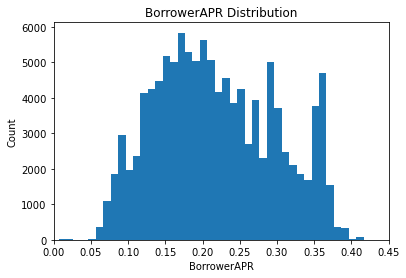

```python
#inspecting the distribution of the BorrowerApr
bins = np.arange(df['BorrowerAPR'].min(), df['BorrowerAPR'].max(), 0.01)
plt.hist(data = df, x = 'BorrowerAPR', bins = bins)
plt.xlim(0, 0.45)
plt.xlabel('BorrowerAPR')
plt.ylabel('Count')
plt.title('BorrowerAPR Distribution');
```

## Observation

> From the histogram chart above, we can see that the BorrowerAPR is normally distributed with a little spike around 0.35

## Question

### What is the distribution of the BorrowerRate

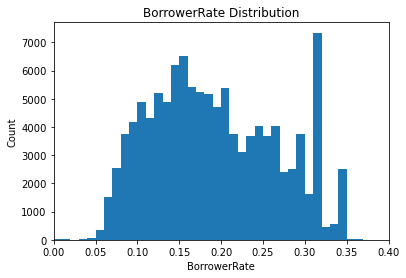

```python
#checking the distribution of the BorrowerRate
bins = np.arange(df['BorrowerRate'].min(), df['BorrowerRate'].max(), 0.01)
plt.hist(data = df, x = 'BorrowerRate', bins = bins)
plt.xlim(0, 0.4)
plt.xlabel('BorrowerRate')
plt.ylabel('Count')
plt.title('BorrowerRate Distribution');
```

## Observation

> The BorrowerRate seems to be slightly right skewed with a high count occurring at 0.32

## Question

### What is the LoansStatus distribution

```python
status_counts = df['LoanStatus'].value_counts()
status_counts_sum = df['LoanStatus'].value_counts().sum()
prop = status_counts[0]/status_counts_sum
prop
```

```
0.4965551137909546
```

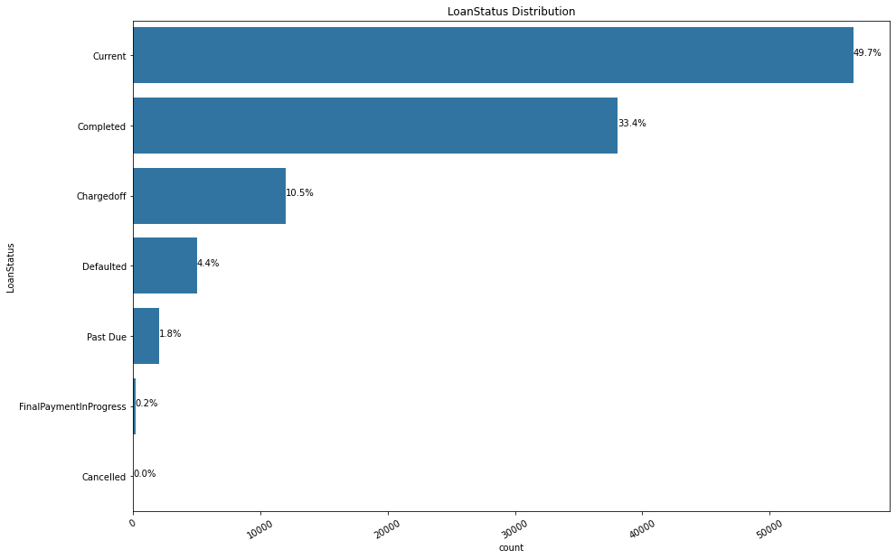

```python
#plotting for the distribution of LoanStatus
base_color = sns.color_palette()[0]
plt.figure(figsize = [15, 10])
for v in range(status_counts.shape[0]):
    f = status_counts[v]
    texts = '{:0.1f}%'.format(100 * f/status_counts_sum )
    plt.text(f, v, texts)
    ordered = df['LoanStatus'].value_counts().index
    sns.countplot(data = df, y= 'LoanStatus', color = base_color, order = ordered)
    plt.xticks(rotation = 30)
    plt.title('LoanStatus Distribution')
```

## Observation

> The LoanStatus barchart shows that 10.5% were charged off from the loan, 4.4% Defaulted and 33.4% completed their loan.

```python
#checking the employment status of the borrowers
counts = df['EmploymentStatus'].value_counts()
counts_sum = df['EmploymentStatus'].value_counts().sum()
prop = counts[0]/counts_sum
prop
```

```
0.6028008094410917
```

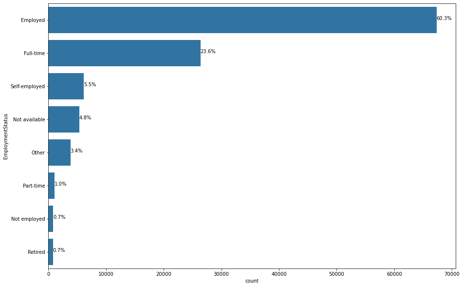

```python
base_color = sns.color_palette()[0]
plt.figure(figsize = [15, 10])
for v in range(counts.shape[0]):
    f = counts[v]
    texts = '{:0.1f}%'.format(100 * f/counts_sum )
    plt.text(f, v, texts)
    ordered = df['EmploymentStatus'].value_counts().index
    sns.countplot(data = df, y= 'EmploymentStatus', color = base_color, order = ordered);
```

> From the bar chart above, it is observed that higher population (60.3%) of the Borrowers are employed.

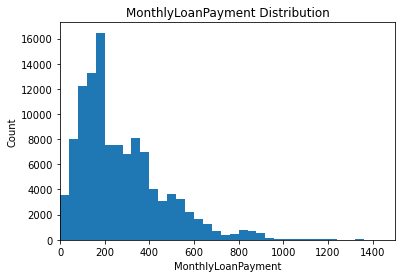

```python
#investigating the distribution of the MonthlyLoanPayment
bins = np.arange(file['MonthlyLoanPayment'].min(), file['MonthlyLoanPayment'].max(), 40)
plt.hist(data = file, x = 'MonthlyLoanPayment', bins = bins)
plt.xlim(0, 1500)
plt.xlabel('MonthlyLoanPayment')
plt.ylabel('Count')
plt.title('MonthlyLoanPayment Distribution');
```

> The MonthlyLoanPayment is right skewed with more people paying about 170 - 200 dollars monthly

```python
s = df['ListingCategory'].value_counts()
s_sum = df['ListingCategory'].value_counts().sum()
s_index = df['ListingCategory'].value_counts().index
```

```python
s_prop = s[0]/s_sum
s_prop
```

```
0.5117564970115064
```

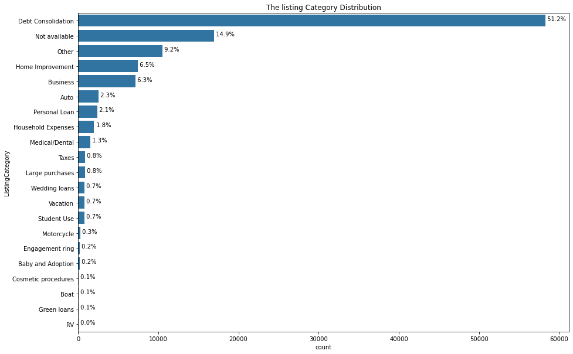

```python
s_ticks = np.arange(0, s_prop, 0.1)
s_ticks
plt.figure(figsize = [15, 10])
for i in range(s.shape[0]):
    c = s[i]
    p = '{: 0.1f}%'.format(100 * c/s_sum)
    plt.text(c+1, i, p )
    base_color = sns.color_palette()[0]

    sns.countplot(data = df, y= 'ListingCategory', color = base_color,order =  s_index)
    plt.title('The listing Category Distribution')
```

> 51.2% of the Borrower's collected the loan for Debt consolidation, that is taking out a new loan to pay off other liabilities and consumer debts.

```python
#making a copy of the dataframe
df_copy = df.copy()
```

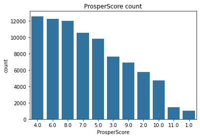

```python
#Creating a bar chart of the relative frequency of the ProsperScore
base_color = sns.color_palette()[0]
index1 = df_copy['ProsperScore'].value_counts().index
sns.countplot(data = df_copy, x = 'ProsperScore', color = base_color, order = index1)
plt.title('ProsperScore count');
```

> More borrowers tend to have a prosperscore of 4, 6, and 8 of 14.84%, 14.47%, and 14.20% respectively

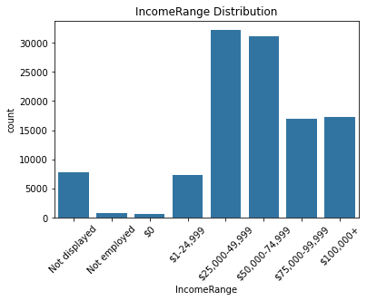

```python
#Creating a bar chart of the relative frequency of the IncomeRange
order = ['Not displayed', 'Not employed', '$0', '$1-24,999', '$25,000-49,999', '$50,000-74,999', '$75,000-99,999', '$100,000+']
base_color = sns.color_palette()[0]
sns.countplot(data = df_copy, x = 'IncomeRange', color = base_color, order = order)
plt.xticks(rotation = 45)
plt.title('IncomeRange Distribution');
```

> 28% of the borrowers are within the income range of 25,000 - 49,999, 27% are within the 50000-74999 range. This implies that more borrower's are in the lower income range.

```python
(df_copy['IncomeRange'].value_counts()/df_copy['IncomeRange'].value_counts().sum())*100
```

```
$25,000-49,999    28.254211
$50,000-74,999    27.251902
$100,000+         15.216304
$75,000-99,999    14.846801
Not displayed      6.794106
$1-24,999          6.384230
Not employed       0.707408
$0                 0.545038
Name: IncomeRange, dtype: float64
```

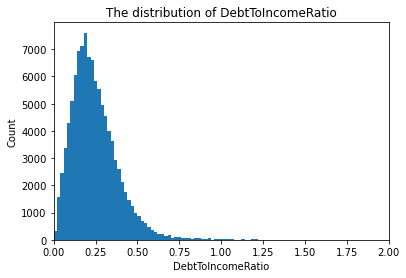

```python
#investigating the 'DebtToIncomeRatio' distribution
bins = np.arange(0, df_copy['DebtToIncomeRatio'].max(), 0.02)
plt.hist(data = df_copy, x = 'DebtToIncomeRatio', bins = bins)
plt.xlim(0, 2)
plt.xlabel('DebtToIncomeRatio')
plt.ylabel('Count')
plt.title('The distribution of DebtToIncomeRatio');
```

> The Debt-to-Income-ratio distribution chart shown above is right skewed, and it describes that most of the borrowers spend 20-25% of their monthly income on paying debts

```python
#checking the number of house owners
df_copy['IsBorrowerHomeowner'].value_counts()
```

```
True     57478
False    56459
Name: IsBorrowerHomeowner, dtype: int64
```

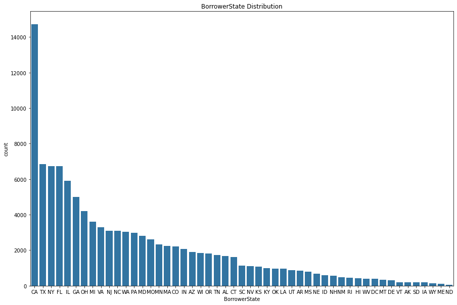

```python
#Looking at the BorrowerState Distribution
ordered = df_copy['BorrowerState'].value_counts().index
plt.figure(figsize = (15, 10))
sns.countplot(data = df_copy, x = 'BorrowerState', color = base_color, order = ordered)
plt.title('BorrowerState Distribution');
```

> CA has the highest number (14717) of Borrowers, while WY, ME and ND have the lowest number of 150, 101, and 52 respectively

## Insights

### Distribution(s) of the variable(s) of interest.

> - The BorrowerAPR variable is normally distributed with a little spike around 0.35
> - The BorrowerRate seems to be slightly right skewed with a high count occurring at 0.32
> - The LoanStatus barchart shows that 10.5% were charged off from the loan, 4.4% Defaulted and 33.4% completed their loan.

> Before the data exploration, I performed some tidying such as changing the 'ListingCategory (numeric)' variable to it's main string values, the LoanOriginationDate datatype was changed to datetime and the loan year was extracted as 'Loan_year'. This was done for easy understanding and exploration of the dataset.

> Aside the main variables of interest, other variables such as the 'EmploymentStatus', 'MonthlyLoanPayment', 'ListingCategory', 'ProsperScore', 'IncomeRange', 'DebtToIncomeRatio', and 'BorrowerState distributions were investigated, and the following was obeserved:
> - Higher population (60.3%) of the Borrowers are employed.
> - The MonthlyLoanPayment is right skewed with more people paying about 170 - 200 dollars monthly.
> - 51.2% of the Borrower's collected the loan for Debt consolidation, that is taking out a new loan to pay off other liabilities and consumer debts.
> - More borrowers tend to have a prosperscore of 4, 6, and 8 of 14.84%, 14.47%, and 14.20% respectively.
> - 28% of the borrowers are within the income range of 25,000 - 49,999, while 27% are within the 50000-74999 range. This implies that more borrower's are in the lower income range.
> - The Debt-to-Income-ratio distribution chart shown above is right skewed, and it describes that most of the borrowers spend 20-25% of their monthly income on paying debts.
> - CA has the highest number of Borrowers.

## Bivariate Exploration

> The next thing is to check the factors that contribute to our main features of interest (the BorrowerAPR, BorrowerRate, and the LoanStatus)

```python
#since the scatter plot is giving us too clustered points, let's create a sample of the dataset
sample = df_copy.sample(1000)
```

## Question

### Is BorrowerAPR correlated to the LoanOriginalAmount and ProsperScore

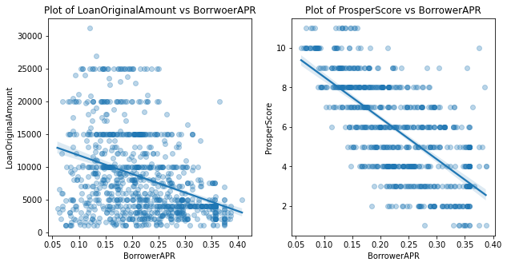

```python
#plotting the LoanOriginalAmount vs BorrowerAPR
plt.figure(figsize =(10, 5))
plt.subplot(1, 2, 1)
sns.regplot(data= sample, x = 'BorrowerAPR', y = 'LoanOriginalAmount', scatter_kws = {'alpha': 0.3})
plt.title('Plot of LoanOriginalAmount vs BorrwoerAPR');

#plotting the ProsperScore vs BorrowerAPR
plt.subplot(1, 2, 2)
sns.regplot(data= sample, x = 'BorrowerAPR', y = 'ProsperScore', scatter_kws = {'alpha': 0.3})
plt.title('Plot of ProsperScore vs BorrowerAPR');
```

## Observation

> The BorrowerAPR showed a slight negatitve correlation with the LoanOriginalAmount, and also a moderate negative correlation with the ProsperScore.

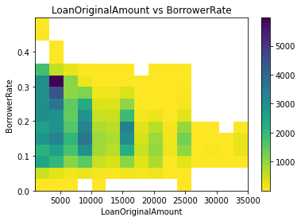

```python
#plotting a histogram of LoanOriginalAmount vs BorrowerRate
plt.hist2d(data = df_copy, x = 'LoanOriginalAmount', y = 'BorrowerRate', cmap = 'viridis_r', cmin = 0.3, bins = 15)
plt.colorbar()
plt.xlabel('LoanOriginalAmount')
plt.ylabel('BorrowerRate')
plt.title('LoanOriginalAmount vs BorrowerRate');
```

> **Insight**

> We can see from the chart above, there is a slight negative correlation between the BorrowerRate and the LoanOriginalAmount.

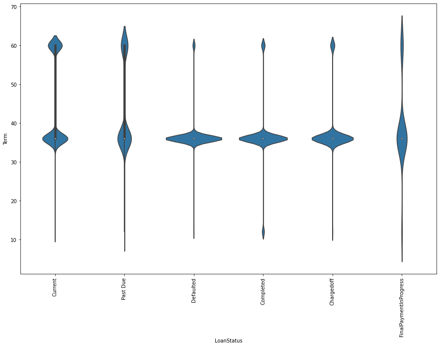

```python
#creating a violin plot for the LoanStatus against the Term of the loan
plt.figure(figsize = (15, 10))
status = ['Current', 'Past Due', 'Defaulted', 'Completed', 'Chargedoff',
       'FinalPaymentInProgress']
List = pd.api.types.CategoricalDtype(ordered = True, categories = status)
df_copy['LoanStatus'] = df_copy['LoanStatus'].astype(List)
sns.violinplot(data = df_copy, x = 'LoanStatus', y = 'Term', color = base_color)
plt.xticks(rotation = 90);
```

> Most of the Loan term appeared to be mostly within 30 - 40 months with little spread occuring at 60 months for the current loan. The Loan term does not affect the loanstatus.

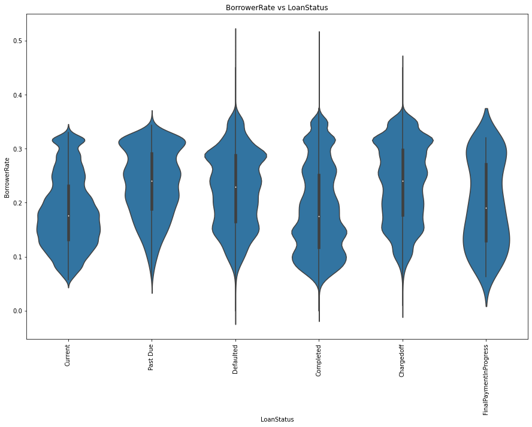

```python
#creating a violin plot for BorrowerRate vs LoanStatus
plt.figure(figsize = (15, 10))
status = ['Current', 'Past Due', 'Defaulted', 'Completed', 'Chargedoff',
       'FinalPaymentInProgress']
List = pd.api.types.CategoricalDtype(ordered = True, categories = status)
df_copy['LoanStatus'] = df_copy['LoanStatus'].astype(List)
sns.violinplot(data = df_copy, x = 'LoanStatus', y = 'BorrowerRate', color = base_color)
plt.xticks(rotation = 90)
plt.title('BorrowerRate vs LoanStatus');
```

> Borrowers with completed and current loanStatus show to have lower BorrowerRate, while those of the pastDue, Defaulted, and chareged off have higher BorrowerRates.

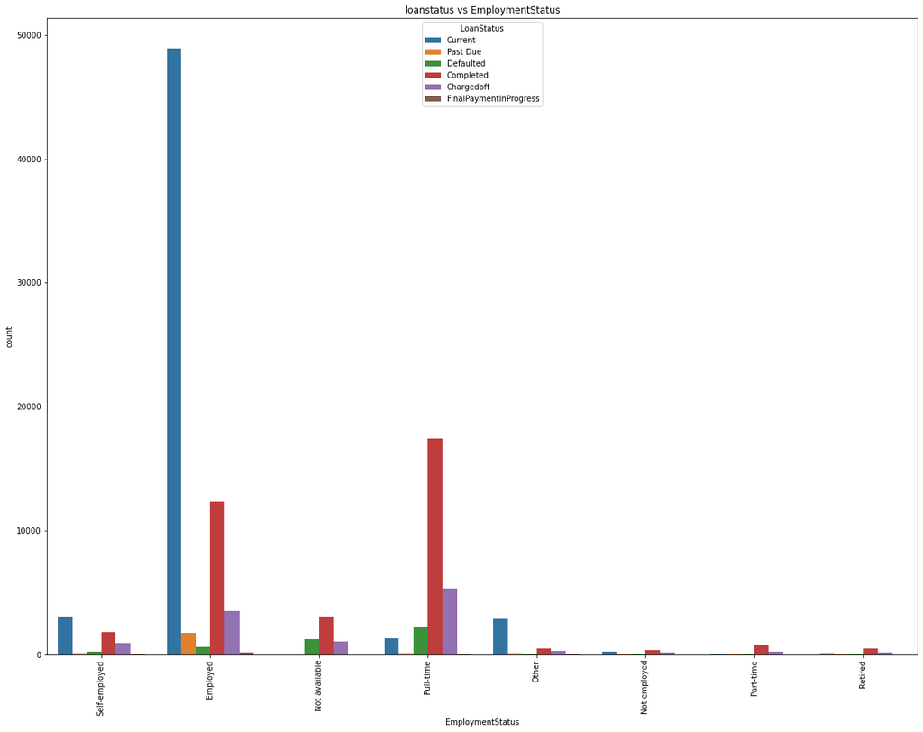

```python
#plotting a clustered barchart for the loanstatus vs EmploymentStatus
plt.figure(figsize = (20, 15))
sns.countplot(data = df_copy, x= 'EmploymentStatus', hue= 'LoanStatus')
plt.xticks(rotation = 90)
plt.title('loanstatus vs EmploymentStatus');
```

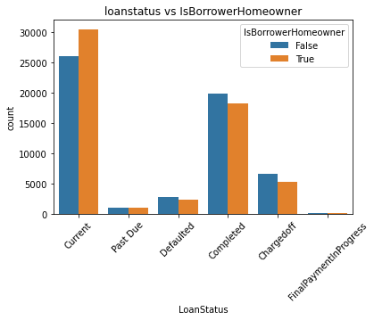

```python
##plotting a clustered barchart for the loanstatus vs IsBorrowerHomeowner
sns.countplot(data = df_copy, x = 'LoanStatus', hue = 'IsBorrowerHomeowner')
plt.xticks(rotation = 45)
plt.title('loanstatus vs IsBorrowerHomeowner');
```

> People who completed their loan are mostly people who are not home owners. This means that Owning a home doesn't determine if a borrower can complete his loan.

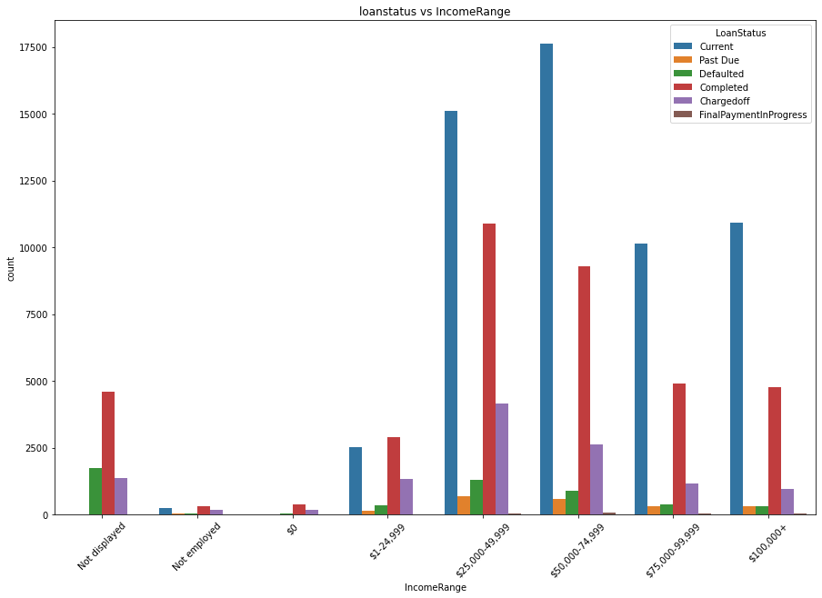

```python
#plotting a clustered barchart for the loanstatus vs IncomeRange
plt.figure(figsize = (15, 10))
sns.countplot(data = df_copy, x = 'IncomeRange', hue = 'LoanStatus', order = order)
plt.xticks(rotation = 45)
plt.title('loanstatus vs IncomeRange');
```

> Most borrowers who completed their Loan are within the income range of $25000-49999 and 50000-74999 dollars

## Question

### How does the Loan year affect the BorrowerRate

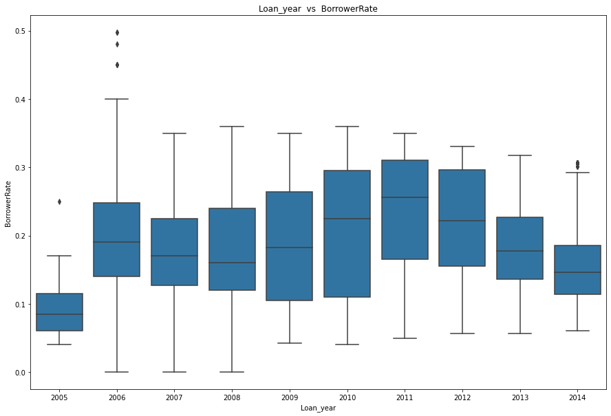

```python
#plotting a boxplot for the Loan_year vs BorrowerRate
base_color = sns.color_palette()[0]
plt.figure(figsize = (15, 10))
sns.boxplot(data = df, x = 'Loan_year', y = 'BorrowerRate', color = base_color)
plt.title('Loan_year  vs  BorrowerRate');
```

## Question

### What is the correlation patterns between the numerical variables

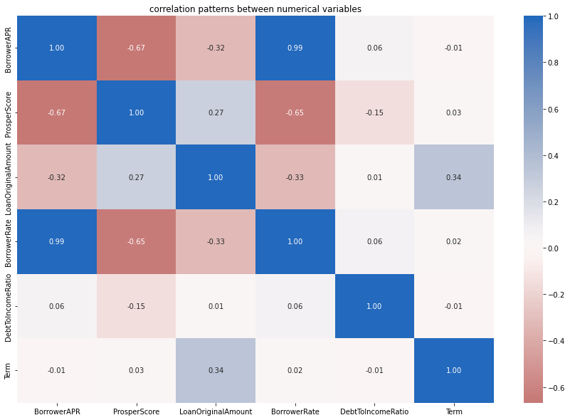

```python
#creating a histogram to identify correlation patterns between numerical variables
plt.figure(figsize = (15, 10))
correlation_variables =df_copy[['BorrowerAPR', 'ProsperScore', 'LoanOriginalAmount', 'BorrowerRate', 'DebtToIncomeRatio', 'Term']]
sns.heatmap(correlation_variables.corr(), annot = True, cmap = 'vlag_r', center = 0, fmt = '.2f')
plt.title('correlation patterns between numerical variables');
```

## Observations

Other correlation includes:

> - **Term** only showed a slight positive correlation with the LoanOriginalAmount.

## Multivariate Exploration

> The essence of this is to dive deeper into understanding the correlations occuring with the main variables of interest

## Question

### What is the ProsperScore of each LoanStatus

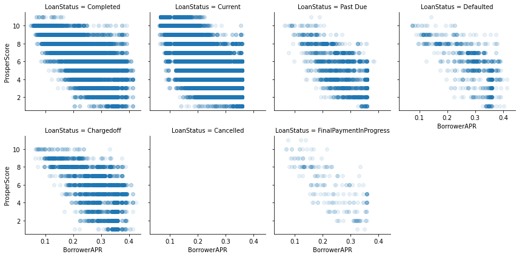

```python
#creating a facetgrid
grid = sns.FacetGrid(data = file, col = 'LoanStatus', col_wrap = 4, height = 3)
grid.map(plt.scatter, 'BorrowerAPR', 'ProsperScore',  alpha = 0.1)
grid.set_xlabels('BorrowerAPR')
grid.set_ylabels('ProsperScore')

plt.show();
```

## Observation

> The borrowers with completed and current loanStatus have higher ProsperScore, while others have lower ProsperScore

## Question

### How is the MonthlyLoanPayment determined by the BorrowerRate vs LoanOriginalAmount

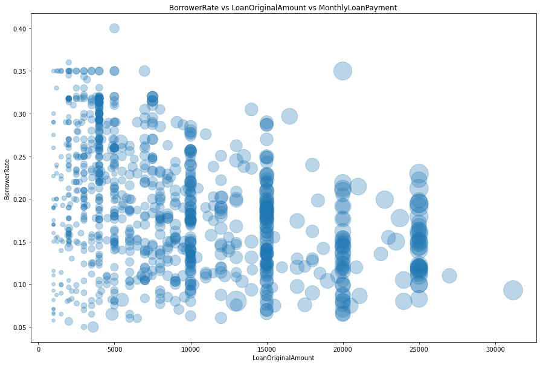

```python
# creating a bubble plot for the relationship between BorrowerRate, LoanOriginalAmount and MonthlyLoanPayment
plt.figure(figsize = (15, 10))
plt.scatter(data = sample, x = 'LoanOriginalAmount', y = 'BorrowerRate',  s ='MonthlyLoanPayment', alpha = 0.3)
plt.xlabel('LoanOriginalAmount')
plt.ylabel('BorrowerRate')
plt.title('BorrowerRate vs LoanOriginalAmount vs MonthlyLoanPayment');
```

## Question

### How does IsBorrowerHomeowner affect BorrowerRate and ProsperScore

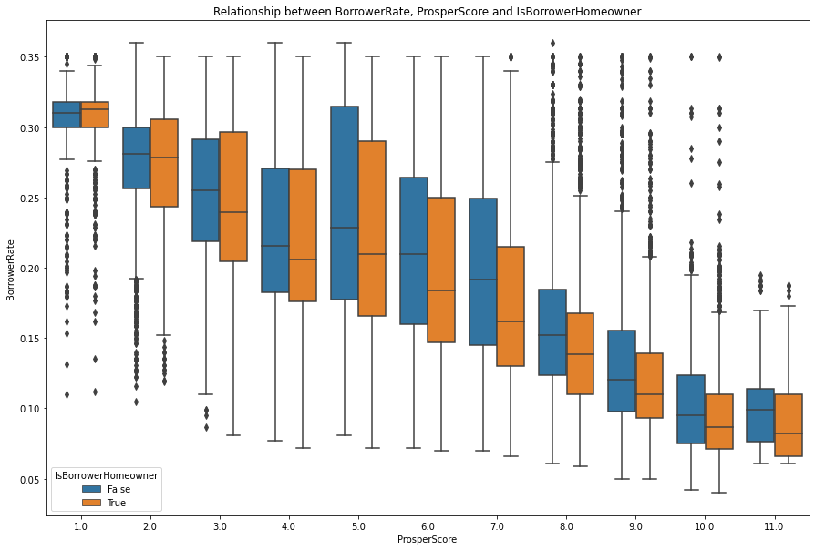

```python
#checking the relationship between BorrowerRate, ProsperScore and IsBorrowerHomeowner
plt.figure(figsize = (15, 10))
sns.boxplot(data = df, x = 'ProsperScore', y = 'BorrowerRate', hue = 'IsBorrowerHomeowner')
plt.title('Relationship between BorrowerRate, ProsperScore and IsBorrowerHomeowner');
```

## Observation

> Looking at the relationship between BorrowerRate VS ProsperScore VS IsBorrowerHomeowner, we can see that homeowners whose prosperscore is below 4 has a higher borrowerrate, while homeowners whose prosperscore is greater has a lower borrowerrate.

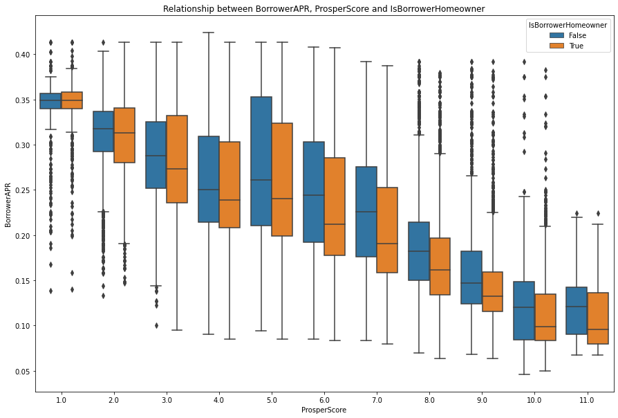

```python
#checking the relationship between BorrowerAPR, ProsperScore and IsBorrowerHomeowner
plt.figure(figsize = (15, 10))
sns.boxplot(data = df, x = 'ProsperScore', y = 'BorrowerAPR', hue = 'IsBorrowerHomeowner')
plt.title('Relationship between BorrowerAPR, ProsperScore and IsBorrowerHomeowner');
```

> The same thing applies to the relationship between BorrowerAPR VS ProsperScore VS IsBorrowerHomeowner, as the BorrowerAPR is strongly correlated to the BorrowerRate.

## Question

### What is the relationship between Term, LoanOriginalAmount and IsBorrowerHomeowner

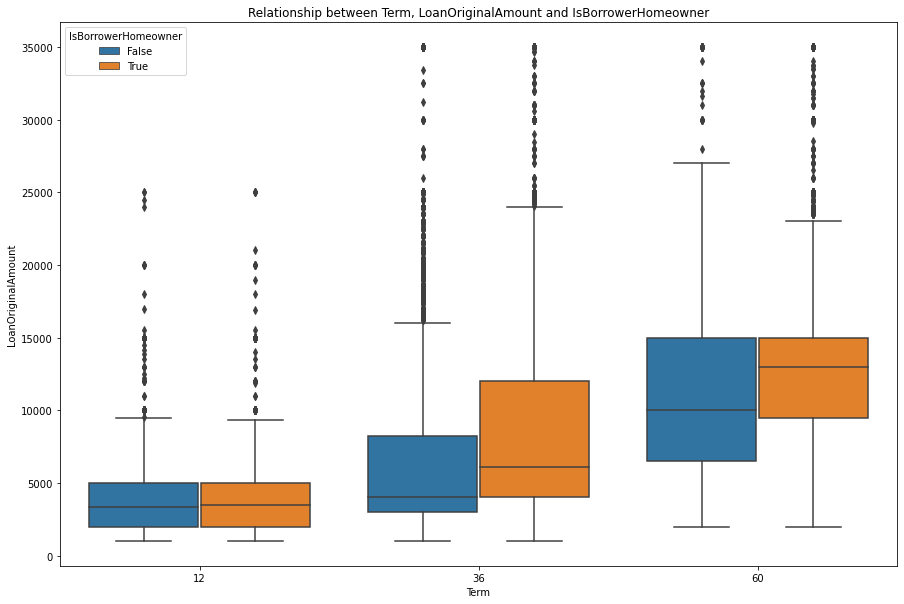

```python
#checking the relationship between Term, LoanOriginalAmount and IsBorrowerHomeowner
plt.figure(figsize = (15, 10))
sns.boxplot(data = df, x = 'Term', y = 'LoanOriginalAmount', hue = 'IsBorrowerHomeowner')
plt.title('Relationship between Term, LoanOriginalAmount and IsBorrowerHomeowner');
```

## Observation

> The Loan Original amount increases with an increase in loan term, and it's slightly higher for homeowners.

## Final Thought

> From all the explorations(univariate, bivariate and multivariate) carried out, it is seen that higher loans with lower rates are been given to people with higher prosper score. These people with lower borrower rate are also seen to be homeowners. The same thing applies to the BorrowerAPR as it is strongly positively correlated to the BorrowerRate.

> Looking at the loanstatus, it is also observed that people who completed their loan payments are mostly people with lower borrower rate, and the LoanStatus is not affected by the term of the loan.